# FormattedFinal

### By: Julian Spencer && Eric Bloom

## Published: December 12, 2022 Last Updated: December 16, 2022

1. Introduction
2. Data Data Wrangling
   1. Meeting the Data
   2. Data Manipulation
3. Porch & Deck Correlations
1. Linear Regression regarding Decks and Porches
2. Comparing Types of Porches with Month Sold
4. Porch Type Distributions
1. Enclosed Porche Area VS Month Sold
2. Screened Porch Area VS Month Sold
3. 3-Season Porch Area VS Month Sold
5. FirePlace Correlation Data
1. Mean Sales Prices by Fireplace and Month Sold
2. Fireplace Qualiy VS Price of House Sold
6. The Garage Trials
1. Trends in Garage Types VS Month of Sale
7. Cold Yet?
1. Number of Houses Sold by Heating/Cooling Quality and Month
8. Proving/Disproving the Null
1. Fitting a Linear Regression Model for Month VS All Amenities
9. Conclusion

The housing market has plenty of factors that keep the numbers changing for home sales, including [seasonality](https://www.nar.realtor/blogs/economists-outlook/seasonality-in-the-housing-market). Past data shows that sales activity increase during the warmer months. We want to find out, given a particular type of house, is there anything that can make it look more appealing during different seasons? We understand there exist a variety of house types, but there are still a finite number of house amenities. We shall take a look at a sample of these features in attempts to seek a correlation between the timing and pricing of the house sold. Specifically, we want to find out what type of features make a house more valuable during certain seasons. We will focus on three amenities: fireplaces, porches/decks,and garage type. To achieve our goal, we plan to use all the skills we aquired over the semester in working with python, pandas, matplotlib, and more to analyze a dataset of home sales data.

Overall, we believe that our analysis will provide valuable insights into the correlation between home sales and seasons, and help us understand which amenities are most valuable in different seasons. We hope that our findings will be useful for homeowners and real estate agents looking to optimize the sale of their homes.

Our null hypothesis suggests that there is no relationship between the number of houses sold during a particular season and the type of amenities of the house.

The dataset of house sales we took is from Ames, Iowa. This dataset contains over 80 columns and needs to be reduced in order to target our focus only on relevant data. The first step would be to import the data for use and to drop any columns that are not related to home amenities. In order to build an effective model, we will need to make sure we identify and work with only relevant columns.

```python
import folium
import requests
import csv
import pandas as pd

house_df = pd.read_csv("house-prices-advanced-regression-techniques/train.csv")
house_df.head()
```

|  | Id | MSSubClass | MSZoning | LotFrontage | LotArea | Street | Alley | LotShape | LandContour | Utilities | ... | PoolArea | PoolQC | Fence | MiscFeature | MiscVal | MoSold | YrSold | SaleType | SaleCondition | SalePrice |
| --- | --- | --- | --- | --- | --- | --- | --- | --- | --- | --- | --- | --- | --- | --- | --- | --- | --- | --- | --- | --- | --- |
| 0 | 1 | 60 | RL | 65.0 | 8450 | Pave | NaN | Reg | Lvl | AllPub | ... | 0 | NaN | NaN | NaN | 0 | 2 | 2008 | WD | Normal | 208500 |
| 1 | 2 | 20 | RL | 80.0 | 9600 | Pave | NaN | Reg | Lvl | AllPub | ... | 0 | NaN | NaN | NaN | 0 | 5 | 2007 | WD | Normal | 181500 |
| 2 | 3 | 60 | RL | 68.0 | 11250 | Pave | NaN | IR1 | Lvl | AllPub | ... | 0 | NaN | NaN | NaN | 0 | 9 | 2008 | WD | Normal | 223500 |
| 3 | 4 | 70 | RL | 60.0 | 9550 | Pave | NaN | IR1 | Lvl | AllPub | ... | 0 | NaN | NaN | NaN | 0 | 2 | 2006 | WD | Abnorml | 140000 |
| 4 | 5 | 60 | RL | 84.0 | 14260 | Pave | NaN | IR1 | Lvl | AllPub | ... | 0 | NaN | NaN | NaN | 0 | 12 | 2008 | WD | Normal | 250000 |

5 rows × 81 columns

We need to gut a majority of the columns since they either prove to be irrelavent for proving our hypothesis, or they just add little predictive power. For this drop any columns describing the house materials, zoning location, structure details, and any data columns that seem biased in distribution. We also rename certain values and sort the data in accordance to the month sold as a convenience for plotting some of our figures.

```python
house_df = house_df.drop(columns = ["LandContour","Utilities","Street","Alley","LandSlope","MasVnrType","Condition2","Heating","Electrical","MasVnrArea","RoofMatl","BsmtFinSF2","BsmtCond","ExterCond","Foundation","GarageFinish","LowQualFinSF","Functional","YearBuilt","YearRemodAdd","ExterQual","MSSubClass","MSZoning","LotConfig","LotFrontage","LotArea","LotShape","MiscFeature","MiscVal","BldgType","HouseStyle","Neighborhood","Id","Condition1","OverallQual","OverallCond","RoofStyle","Exterior1st","Exterior2nd","BsmtQual","BsmtExposure","BsmtFinType1","BsmtFinSF1","BsmtFinType2","BsmtUnfSF","TotalBsmtSF","1stFlrSF","2ndFlrSF","GrLivArea","BsmtHalfBath","BsmtFullBath","BedroomAbvGr","KitchenAbvGr","KitchenQual","TotRmsAbvGrd","GarageYrBlt","GarageCars","FullBath","HalfBath","GarageCond","Fence","SaleType","SaleCondition","PavedDrive","GarageArea","GarageQual","PoolArea","PoolQC"])
```

```python
house_df.rename(columns = {'3SsnPorch':'SeasonalPorch'}, inplace=True)
```

```python
## Replace the initial values of the entries in the MoSold column from integers to strings that represent
## the months of the year
house_df['MoSold'].replace(1,'Jan',inplace=True)
house_df['MoSold'].replace(2,'Feb',inplace=True)
house_df['MoSold'].replace(3,'Mar',inplace=True)
house_df['MoSold'].replace(4,'Apr',inplace=True)
house_df['MoSold'].replace(5,'May',inplace=True)
house_df['MoSold'].replace(6,'June',inplace=True)
house_df['MoSold'].replace(7,'July',inplace=True)
house_df['MoSold'].replace(8,'Aug',inplace=True)
house_df['MoSold'].replace(9,'Sept',inplace=True)
house_df['MoSold'].replace(10,'Oct',inplace=True)
house_df['MoSold'].replace(11,'Nov',inplace=True)
house_df['MoSold'].replace(12,'Dec',inplace=True)
```

```python
 months = { "Jan": 1,
         "Feb": 2,
         'Mar': 3,
         'Apr': 4,
         'May': 5,
         'June': 6,
         'July': 7,
         'Aug': 8,
         'Sept': 9,
         'Oct': 10,
         'Nov': 11,
         'Dec': 12,
    }

def month(series):

    return series.apply(lambda x: months.get(x, 1000))

house_df.sort_values(by=['MoSold'], key = month, inplace=True)
house_df
```

|  | HeatingQC | CentralAir | Fireplaces | FireplaceQu | GarageType | WoodDeckSF | OpenPorchSF | EnclosedPorch | SeasonalPorch | ScreenPorch | MoSold | YrSold | SalePrice |
| --- | --- | --- | --- | --- | --- | --- | --- | --- | --- | --- | --- | --- | --- |
| 729 | TA | Y | 0 | NaN | Detchd | 0 | 23 | 112 | 0 | 0 | Jan | 2009 | 103000 |
| 691 | Ex | Y | 2 | Ex | Attchd | 382 | 50 | 0 | 0 | 0 | Jan | 2007 | 755000 |
| 711 | Gd | Y | 0 | NaN | Detchd | 68 | 0 | 98 | 0 | 0 | Jan | 2010 | 102776 |
| 59 | Ex | Y | 0 | NaN | Detchd | 196 | 0 | 0 | 0 | 0 | Jan | 2008 | 124900 |
| 787 | Ex | Y | 0 | NaN | BuiltIn | 0 | 45 | 0 | 0 | 0 | Jan | 2010 | 233000 |
| ... | ... | ... | ... | ... | ... | ... | ... | ... | ... | ... | ... | ... | ... |
| 574 | TA | Y | 0 | NaN | BuiltIn | 35 | 0 | 0 | 0 | 0 | Dec | 2007 | 139000 |
| 707 | Ex | Y | 1 | Gd | Attchd | 192 | 38 | 0 | 0 | 0 | Dec | 2009 | 254000 |
| 573 | Ex | Y | 1 | TA | BuiltIn | 100 | 0 | 0 | 0 | 0 | Dec | 2007 | 170000 |
| 1296 | Gd | Y | 0 | NaN | Attchd | 192 | 20 | 123 | 0 | 0 | Dec | 2008 | 155000 |
| 720 | TA | Y | 1 | TA | Attchd | 114 | 28 | 234 | 0 | 0 | Dec | 2006 | 275000 |

1460 rows × 13 columns

### 3.A.) Linear Regression regarding Decks and Porches

The first feature we investigate are the porches and decks. These plots show the relationship between the sale price vs the area of the porches. We first filter the data to only include houses that have a non-zero area for the respective porch type, in order to exclude houses without a porch and avoid bias. Then, we use the scikit-learn library's LinearRegression class to fit a linear regression model to the data for each porch type. The resulting model is then used to generate predictions for porch area values between the minimum and maximum observed values. Finally, we print the slope of the fitted regression lines, and create scatter plots of the observed data with the fitted regression lines overlaid.

```
Slope for Wood Deck Area vs House Price Regression: 149.854728
Slope for Open Porch Area vs House Price Regression: 106.935459
```

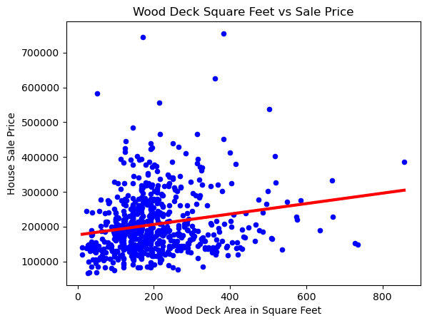

[figure not shown]

```python
import matplotlib.pyplot as plt
import numpy as np
from sklearn.linear_model import LinearRegression

wood = house_df.query('WoodDeckSF != 0')
porch = house_df.query('OpenPorchSF != 0')

X_wood = wood['WoodDeckSF'].values.reshape(-1,1)
X_porch = porch['OpenPorchSF'].values.reshape(-1,1)
Y_w = wood['SalePrice'].values
Y_p = porch['SalePrice'].values

reg = LinearRegression()
reg2 = LinearRegression()

prediction_wood = np.linspace(min(X_wood), max(X_wood)).reshape(-1, 1)
prediction_porch = np.linspace(min(X_porch), max(X_porch)).reshape(-1, 1)

reg.fit(X_wood, Y_w)
reg2.fit(X_porch, Y_p)

wood_pred = reg.predict(prediction_wood)
porch_pred = reg2.predict(prediction_porch)
print('Slope for Wood Deck Area vs House Price Regression: %f'%reg.coef_[0])
print('Slope for Open Porch Area vs House Price Regression: %f'%reg2.coef_[0])

wood.plot.scatter('WoodDeckSF','SalePrice', color= 'b')
plt.plot(prediction_wood, wood_pred, color='red', linewidth=3)
plt.title("Wood Deck Square Feet vs Sale Price")
plt.xlabel('Wood Deck Area in Square Feet')
plt.ylabel('House Sale Price')
porch.plot.scatter('OpenPorchSF','SalePrice', color= 'b')
plt.plot(prediction_porch, porch_pred, color='red', linewidth=3)
plt.title("Porch Square Feet vs Month Sold")
plt.xlabel("Open porch Area in Square Feet")
plt.show()
```

With some notable exceptions, we see that the data is skewed towards having a lower average porch area, with a lower general sales price. We can also notice that on average wooden decks have more square area than an open porch. This correlates to the regression lines generated because the slope for wooden deck area vs price is slightly higher than the slope from open porch area vs price. The regression lines generated have a very small increasing slope, but yet still shows that as the porch area increases so does the price of the house.

Based on this information, it is hard to say if having an open porch vs a wooden deck has any more influence on the price of the house by itself. But it is fairly likely that houses with larger porches will have a higher sale price. Additionally, since the data shows that the relationship between open porch area and sale price is weak, it may prove more useful to focus on seasonal purchasing trends.

The purpose of this code is to create scatter plots of three different porch areas (enclosed, screened, and 3-season) versus the month in which the house was sold. The data is filtered to only include houses that have a non-zero area for the respective porch type, and the resulting data is plotted using matplotlib's scatter() function. The color of each plotted point corresponds to the porch type (enclosed porches are red, screened porches are blue, and 3-season porches are green).

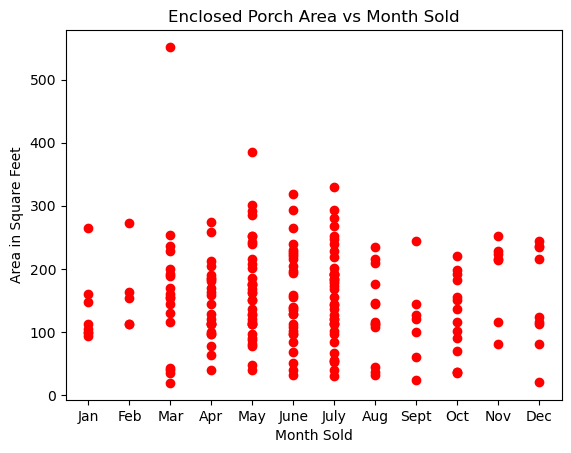

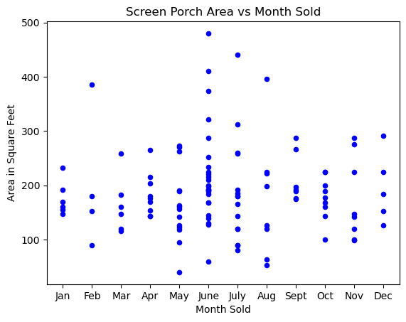

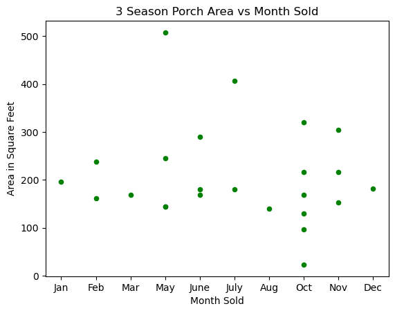

```python
closed = house_df.query('EnclosedPorch != 0')
screen = house_df.query('ScreenPorch != 0')
season = house_df.query('SeasonalPorch != 0')

plt.scatter(closed['MoSold'],closed['EnclosedPorch'], color= 'r')
plt.title("Enclosed Porch Area vs Month Sold")
plt.xlabel("Month Sold")
plt.ylabel('Area in Square Feet')
screen.plot.scatter('MoSold','ScreenPorch', color= 'b')
plt.title("Screen Porch Area vs Month Sold")
plt.xlabel('Month Sold')
plt.ylabel('Area in Square Feet')
season.plot.scatter('MoSold','SeasonalPorch', color= 'g')
plt.title('3 Season Porch Area vs Month Sold')
plt.xlabel('Month Sold')
plt.ylabel('Area in Square Feet')
```

The next plot would be for screened porch area (Blue). We can tell right off the bat that these type of houses are less in quantity, thus we see that the scatterplot data is more sparse for this type of porch. You can work out a very slight increasing trend amoung the amount of square footage of porch a house is sold with. Just like with the enclosed porch area, we see a huge spike in sales in the summer months of June and July, but this time the datapoints are mainly outliers as we see the majority of the large screened porches (>300 Square Feet) being sold.

Lastly, we see that the three season porch plot is even more sparse then the screened porches before it. This makes it very difficult to see if a 3 season porch has any correlation with month at all. More data of houses with 3 season porch sales will be needed to say something about it's trend. Still, it is interesting to see that the outliers for large seasonal porches only exist during the warmer months where having a nice porch is more desirable.

We would like to better examine the trend of the porch area a house has vs the month it was sold. We can accomplish this by making a violin plot of each.

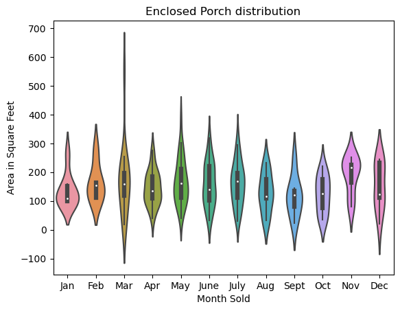

```python
import seaborn

fig, ax = plt.subplots()

seaborn.violinplot(ax = ax,
               data = closed,
               x = 'MoSold',
               order = ['Jan','Feb','Mar','Apr','May','June','July','Aug','Sept','Oct','Nov','Dec'],
               y = 'EnclosedPorch',
               hue = None,
               split = True)
plt.title("Enclosed Porch distribution")
plt.xlabel('Month Sold')
plt.ylabel('Area in Square Feet')
plt.show()
```

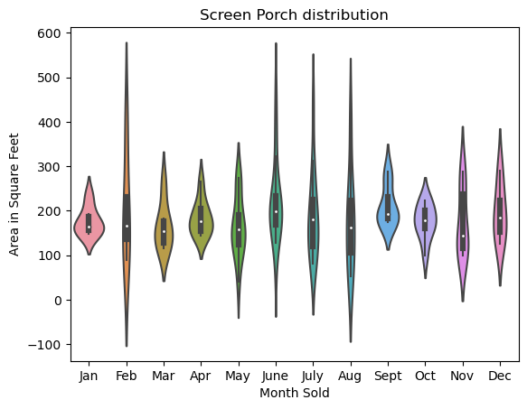

```python
fig, ax = plt.subplots()

seaborn.violinplot(ax = ax,
               data = screen,
               x = 'MoSold',
                order=['Jan','Feb','Mar','Apr','May','June','July','Aug','Sept','Oct','Nov','Dec'],
               y = 'ScreenPorch',
               hue = None,
               split = True)
plt.title("Screen Porch distribution")
plt.xlabel('Month Sold')
plt.ylabel('Area in Square Feet')
plt.show()
```

There seems to be a correlation of a very bottom-heavy distribution for the months of January, april, and september. This is similar to what was found above with enclosed porches as January had a similar distrubution, but with more datapoints. All other distributions per month have relativly symmetric distribution. Again however, we do see that the summer months have a very different distribution than the rest of the months. This is supported from the background knowledge we had about home sale trends picking up pace in the summer. Unfortunately this does not help our hypothesis.

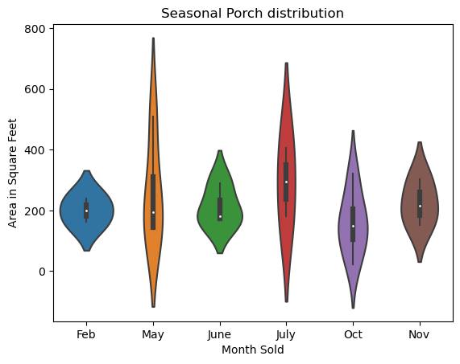

```python
fig, ax = plt.subplots()

seaborn.violinplot(ax = ax,
               data = season,
               x = 'MoSold',
                   order=['Feb','May','June','July','Oct','Nov'],
               y = 'SeasonalPorch',
               hue = None,
               split = True)
plt.title("Seasonal Porch distribution")
plt.xlabel('Month Sold')
plt.ylabel('Area in Square Feet')
plt.show()
```

This plot cannot be compared as much to the other two above as we know from the scatter plot that there is less datapoints for seasonal porches. We can see that Febuary, June, and Novermber has short and thick mostly symmetrical distributions while May, July, and October had more elongated symmetrical distributions. Yet, it is interesting to note that July has the highest mean of seasonal porch area, where we already know house sales are higher. Nonetheless, there was no evidence given from the sparse scatterplot that this results from a greater number of houses sold during July, as we see more being sold in October with smaller porch areas. More data is necessary to know for sure.

Moving on, we want to see if there is some sort of correlation with the number of fireplaces a house is sold with within a given month versus the sale price of the house. Specifically, we would like to focus on any correlation that shows up relating to fireplace sales in the winter months.

```python
## Group the data by the 'Fireplace' column and the 'MoSold' column
grouped_data = house_df.groupby(['Fireplaces', 'MoSold'])

## Calculate the mean sales price for each group
mean_sales_price = grouped_data['SalePrice'].mean()
```

```python
## Unstack the grouped data to create a DataFrame with one column per 'Fireplace' value
unstacked_data = mean_sales_price.unstack(level=0)
unstacked_data.sort_values(by=['MoSold'], key = month, inplace=True)
## NOTE: This call is static and cannot be ran twice without errors
```

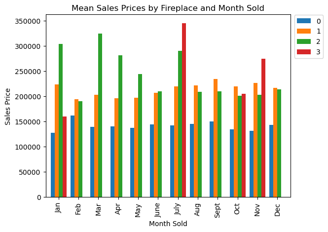

```python
## Plot the resulting DataFrame using a bar chart
unstacked_data.plot(kind='bar', width=0.8)
plt.title("Mean Sales Prices by Fireplace and Month Sold")
plt.xlabel("Month Sold")
plt.ylabel("Sales Price")
plt.legend(bbox_to_anchor=(1.149,1.017))
plt.show()
```

We originally considered dropping the 'FireplaceQu' column due to a high percentage of NAN values. This column captures data surrounding the quality of the fireplace. We decided to analyze the fewer non-NAN values we had in relation to the home sale prices. The "Ex" value correlates with excellent quality, the "Gd" with good quality, "Fa" with fair quality, "Ta" with typical, and "Po" with poor quality.

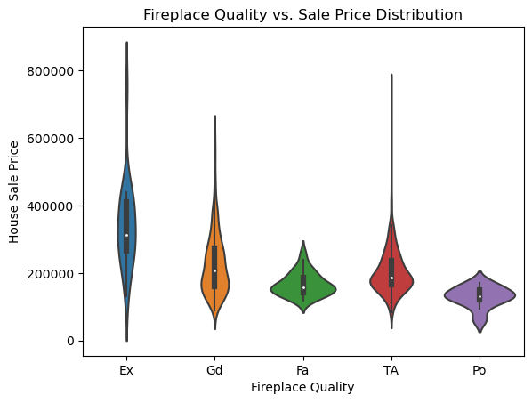

```python
fig, ax = plt.subplots()
seaborn.violinplot(ax = ax,
               data = house_df,
               x = 'FireplaceQu',
               y = 'SalePrice',
               hue = None,
               split = True)
plt.title("Fireplace Quality vs. Sale Price Distribution")
plt.ylabel('House Sale Price')
plt.xlabel('Fireplace Quality')
plt.show()
```

Just looking at the violinplot, we dont see much of a price change between a house with a fireplace in good condition or fair/typical condition. However, to little surprise we do see a trend in lower house pricing for houses with poor quality fireplaces, and higher pricing for houses with fireplaces of excellent quality.

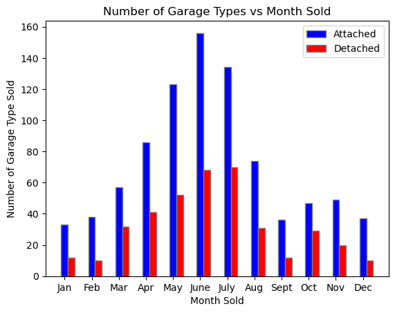

```python
X = ['Jan','Feb','Mar','Apr','May','June','July','Aug','Sept','Oct','Nov','Dec']
det = []
att = []
for i in range(0,12):
    month = house_df.loc[house_df['MoSold'] == X[i]]
    month_att = month['GarageType'].value_counts()['Attchd']
    month_det = month['GarageType'].value_counts()['Detchd']
    att.append(month_att)
    det.append(month_det)


br1 = np.arange(len(X))
br2 = [X + 0.25 for X in br1]
plt.bar(X,att,color='blue', width = 0.25,
        edgecolor ='grey', label ='Attached')
plt.bar(br2,det, color='red', width = 0.25,
        edgecolor ='grey', label ='Detached')
plt.legend()
plt.title("Number of Garage Types vs Month Sold")
plt.xlabel('Month Sold')
plt.ylabel('Number of Garage Type Sold')
plt.show()
```

Here we see an obvious normal distribution from both attached and detached garage types with an ever so slight left tail. The number of sales for homes with attached garages steadily rise from January through June, where they peak and then take a sudden and drastic decline which continues until September. This general trend follows for detached garage sales as well. At this point there does seem to be more evidence of a possible correlation with most ammentities and the summer season rather than the winter season which should be examined further.

Here we can set out to see if there is a correlation with AC quality and purchases in the winter season versus the summer season.

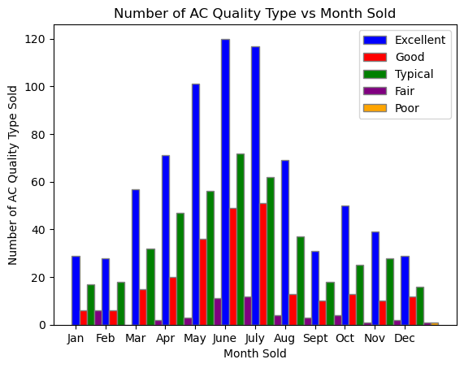

```python
barWidth = 0.25
ex = []
gd = []
ta = []
fa = []
po = []

for i in range(0,12):
    month = house_df.loc[house_df['MoSold'] == X[i]]
    if 'Ex' in month.values:
        E = month['HeatingQC'].value_counts()['Ex']
        ex.append(E)
    else:
        ex.append(0)

    if 'Gd' in month['HeatingQC'].values:
        G = month['HeatingQC'].value_counts()['Gd']
        gd.append(G)
    else:
        gd.append(0)

    if 'Fa' in month['HeatingQC'].values:
        F = month['HeatingQC'].value_counts()['Fa']
        fa.append(F)
    else:
        fa.append(0)

    if 'TA' in month['HeatingQC'].values:
        T = month['HeatingQC'].value_counts()['TA']
        ta.append(T)
    else:
        ta.append(0)

    if 'Po' in month['HeatingQC'].values:
        P = month['HeatingQC'].value_counts()['Po']
        po.append(P)
    else:
        po.append(0)

br1 = np.arange(len(X))
br2 = [X + barWidth for X in br1]
br3 = [X + barWidth for X in br2]
br4 = [X + barWidth for X in br3]
br5 = [X + barWidth for X in br4]

plt.bar(X,ex,color='blue', width = barWidth,
        edgecolor ='grey', label ='Excellent')
plt.bar(br2,gd, color='red', width = barWidth,
        edgecolor ='grey', label ='Good')
plt.bar(br3,ta, color='green', width = barWidth,
        edgecolor ='grey', label ='Typical')
plt.bar(br4,fa, color='purple', width = barWidth,
        edgecolor ='grey', label ='Fair')
plt.bar(br5,po, color='orange', width = barWidth,
        edgecolor ='grey', label ='Poor')
plt.legend()
plt.title('Number of AC Quality Type vs Month Sold')
plt.xlabel('Month Sold')
plt.ylabel('Number of AC Quality Type Sold')
plt.show()
```

We want to set up a models where the dependent variables resembles the month that house was sold while using ALL the amenities examined above as the independent variables.

```python
import statsmodels.formula.api as smf
from sklearn.preprocessing import LabelEncoder
le = LabelEncoder()
# Fit the encoder to the MoSold column and transform the values to be numeric
house_df['MoSold_num'] = le.fit_transform(house_df['MoSold'])
formula = 'MoSold_num ~ HeatingQC + Fireplaces + GarageType + WoodDeckSF + OpenPorchSF + SeasonalPorch + ScreenPorch + EnclosedPorch'
# fit the model to the data
model = smf.ols(formula, data=house_df).fit()
print(model.summary())
```

```
                            OLS Regression Results
==============================================================================
Dep. Variable:             MoSold_num   R-squared:                       0.014
Model:                            OLS   Adj. R-squared:                  0.003
Method:                 Least Squares   F-statistic:                     1.304
Date:                Fri, 16 Dec 2022   Prob (F-statistic):              0.192
Time:                        21:05:22   Log-Likelihood:                -3510.1
No. Observations:                1379   AIC:                             7052.
Df Residuals:                    1363   BIC:                             7136.
Df Model:                          15
Covariance Type:            nonrobust
=========================================================================================
                            coef    std err          t      P>|t|      [0.025      0.975]
-----------------------------------------------------------------------------------------
Intercept                 5.0828      1.287      3.948      0.000       2.557       7.608
HeatingQC[T.Fa]           1.0296      0.513      2.007      0.045       0.023       2.036
HeatingQC[T.Gd]           0.1564      0.245      0.638      0.523      -0.324       0.637
HeatingQC[T.Po]          -3.3826      3.124     -1.083      0.279      -9.512       2.747
HeatingQC[T.TA]          -0.0095      0.205     -0.046      0.963      -0.411       0.392
GarageType[T.Attchd]      0.0525      1.279      0.041      0.967      -2.456       2.561
GarageType[T.Basment]     0.7282      1.459      0.499      0.618      -2.135       3.591
GarageType[T.BuiltIn]     0.7249      1.321      0.549      0.583      -1.867       3.317
GarageType[T.CarPort]     1.3333      1.641      0.812      0.417      -1.886       4.553
GarageType[T.Detchd]      0.2238      1.283      0.174      0.862      -2.293       2.740
Fireplaces                0.1941      0.141      1.374      0.170      -0.083       0.471
WoodDeckSF            -7.858e-05      0.001     -0.113      0.910      -0.001       0.001
OpenPorchSF               0.0005      0.001      0.389      0.697      -0.002       0.003
SeasonalPorch             0.0061      0.003      2.173      0.030       0.001       0.012
ScreenPorch               0.0013      0.002      0.839      0.402      -0.002       0.004
EnclosedPorch             0.0003      0.001      0.216      0.829      -0.003       0.003
==============================================================================
Omnibus:                      126.381   Durbin-Watson:                   0.053
Prob(Omnibus):                  0.000   Jarque-Bera (JB):               51.424
Skew:                          -0.255   Prob(JB):                     6.81e-12
Kurtosis:                       2.203   Cond. No.                     6.23e+03
==============================================================================

Notes:
[1] Standard Errors assume that the covariance matrix of the errors is correctly specified.
[2] The condition number is large, 6.23e+03. This might indicate that there are
strong multicollinearity or other numerical problems.
```

Based on the p-values in the statistical summary, it seems that most of the features in the model do not have a significant effect on the dependent variable. The two exceptions are Fair Heating Quality and Seasonal Porches, which have p-values less than 0.05 and therefore show stronger statistical evidence against the null hypothesis. However these data columns only have a small number of datapoints, which may not be enough to reliably conclude that they have a significant effect on the dependent variable.

Based on our analysis of data from 2006 to 2010, we found that there were only some weak correlations between some amenities and summer seasons, but not for winter seasons. One factor that could have influenced these trends is the [2008 market crash](https://www.uwp.edu/learn/departments/economics/upload/gwartney-summary-of-financial-crisis.pdf), which was a major economic recession that had a significant impact on the housing market. Since our data only spans over a short time period, it may be possible that the relationships between house amenities and seasonal sales differ outside this time frame and in different geographic regions. Another factor influencing the lack of correlation could simply be that the majority of house buyers have higher priorities when looking for a house, more important to them than the amendities.

Looking at our data plots, we can notice that different types of a certain house feature follow the distributions the same. This is a sign that no type of amentity has a significantly powerful influence in the housing market based on this data. The first signs of this was shown in our figures plotting the house sale price against the amentity types. In these figures we saw very small positive slopes and evenly leveled distributions that show no trends. For example, when graphing the number of fireplaces by the sale price of the house, we see that for each bar color the slope remains fairly constant with very few exceptions. With little evidence of a trend, we can not reasonably prove our hypothesis to be correct. Also the p-values generated using Ordinary Least Squares only showed 2 values that were less than 0.05, and these were the amentity types that had insufficient data. Therefore, with the absence of any relevant p-value less than 0.05, we must fail to reject our null hypothesis.